# Bayesian Linear Regression

```r
summary(mcmc.out)
```

```
Iterations = 1:900
Thinning interval = 1
Number of chains = 1
Sample size per chain = 900

1. Empirical mean and standard deviation for each variable,
   plus standard error of the mean:

              Mean      SD  Naive SE Time-series SE
beta      0.751890 0.03353 0.0011176      0.0009796
intercept 0.001473 0.03484 0.0011612      0.0011612
sigma     0.659297 0.02489 0.0008296      0.0009162

2. Quantiles for each variable:

             2.5%      25%      50%     75%   97.5%
beta       0.6822  0.72873 0.752314 0.77459 0.81733
intercept -0.0681 -0.02143 0.002054 0.02255 0.07331
sigma      0.6144  0.64051 0.658968 0.67656 0.70610
```

From R’s lm above: intercept = 5.794e-17 (~ 0) weight = 7.547e-01 sigma = 0.6569515

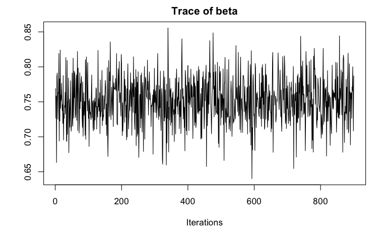

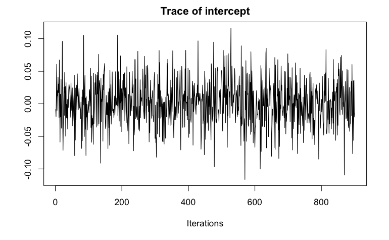

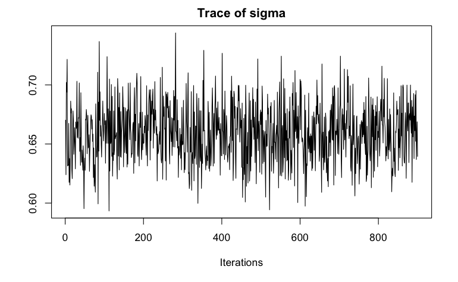

```r
library(coda)
traceplot(mcmc.out)
```

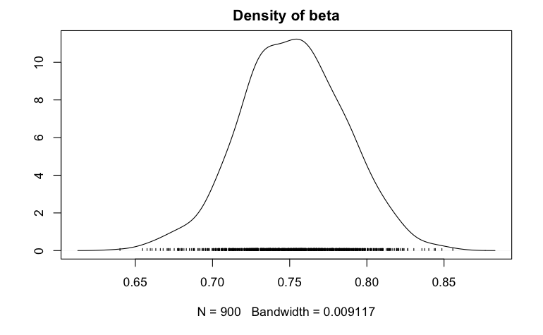

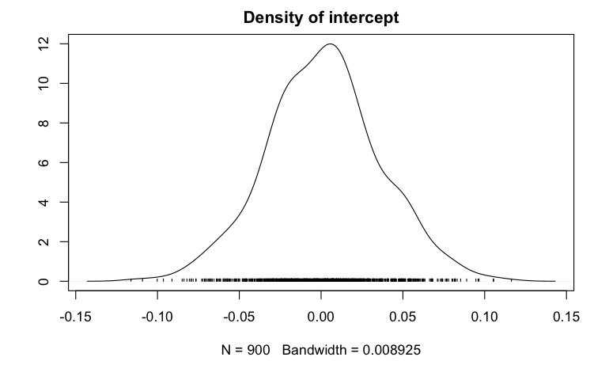

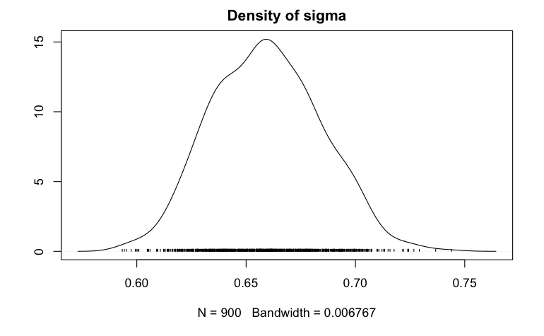

```r
densplot(mcmc.out)
```

6. We fit the linear model using the rstan package in R, which is an interface to Stan (outside of R). Report the parameter estimates for the intercept, effect of height, and sigma. Are they the same as from ‘lm’?

```r
library("rstan")
# options(mc.cores = parallel::detectCores())
# rstan_options(auto_write = TRUE)

kung_dat <- list(N=dim(d3)[1],weight = d3$weight,height = d3$height)

fit <- stan(file = 'lm.stan', data = kung_dat,
            iter=10000, warmup=2500,thin=10,chains=4)
print(fit,pars=c('intercept','beta','sigma'),digits_summary = 3,
      probs = c(0.025,0.5,0.975))
```

```
Inference for Stan model: lm.
4 chains, each with iter=10000; warmup=2500; thin=10;
post-warmup draws per chain=750, total post-warmup draws=3000.

           mean se_mean    sd   2.5%   50% 97.5% n_eff  Rhat
intercept 0.001   0.001 0.034 -0.068 0.001 0.066  2979 1.000
beta      0.755   0.001 0.035  0.684 0.755 0.822  2890 1.000
sigma     0.659   0.000 0.025  0.611 0.658 0.711  3049 0.999

Samples were drawn using NUTS(diag_e) at Thu Jun  3 17:41:03 2021.
For each parameter, n_eff is a crude measure of effective sample size,
and Rhat is the potential scale reduction factor on split chains (at
convergence, Rhat=1).
```

[output not shown]

compared to R’s lm above: intercept = 5.794e-17 (~ 0) weight = 7.547e-01 sigma = 0.6569515

```
ci_level: 0.8 (80% intervals)
outer_level: 0.95 (95% intervals)
```

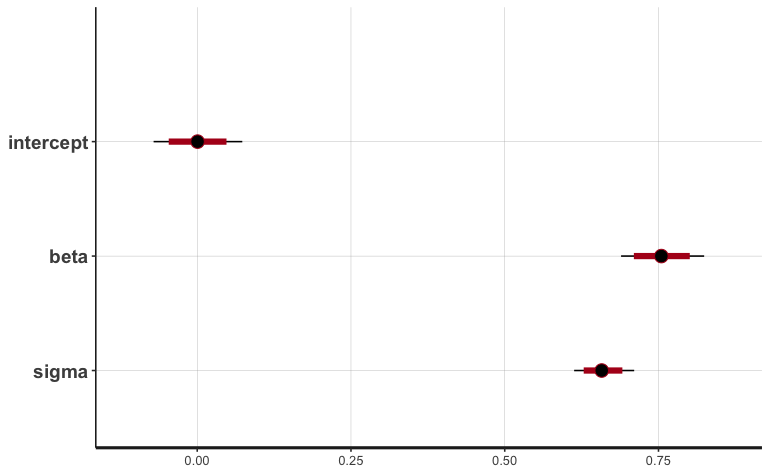

```r
plot(fit)
```

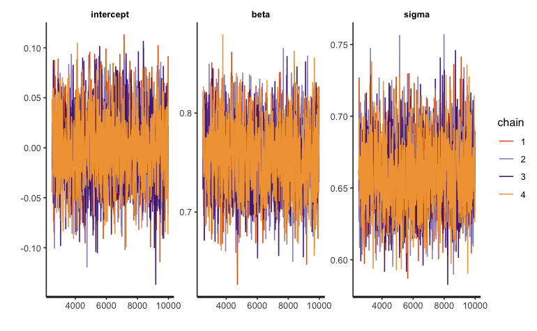

```r
# pairs(fit,c('intercept','beta','sigma'),las=1)
traceplot(fit)
```